# Exploring cell-cell interaction with blisa

Source: [`vignettes/xenium.Rmd`](https://github.com/ChenLaboratory/blisa/blob/main/vignettes/xenium.Rmd)

## Introduction

`blisa` identifies spatially enriched ligand-receptor (LR) interactions from spatial transcriptomics data using bivariate Local Moran’s I (LISA) statistics. The core idea is to bin cells into a hexagonal grid, compute spatial co-enrichment of every ligand-receptor pair across bins, and flag “High-High” hotspot bins where both partners are spatially co-expressed beyond chance.

This vignette walks through a typical workflow on a Xenium breast cancer dataset.

## Load Package

```r
library(blisa)
library(SpatialExperiment)
```

## Load Example Data

The example dataset is a small `SpatialExperiment` object (one Xenium breast cancer section) hosted as a GitHub Release asset. Download it once and cache locally:

```r
data_url   <- "https://github.com/ChenLaboratory/example_data/releases/download/v1.0.0/spe_xenium_bc_s1rep1.rds"
cache_dir  <- tools::R_user_dir("blisa", "cache")
data_file  <- file.path(cache_dir, "spe_xenium_bc_s1rep1.rds")

if (!file.exists(data_file)) {
  dir.create(cache_dir, recursive = TRUE, showWarnings = FALSE)
  download.file(data_url, data_file, mode = "wb")
}

spe <- readRDS(data_file)
spe
```

```
#> class: SpatialExperiment
#> dim: 313 163797
#> metadata(0):
#> assays(1): counts
#> rownames(313): ABCC11 ACTA2 ... ZEB2 ZNF562
#> rowData names(3): ID Symbol Type
#> colnames(163797): cell_1 cell_2 ... cell_167779 cell_167780
#> colData names(12): cell_id transcript_counts ... gene_counts cell_type
#> reducedDimNames(0):
#> mainExpName: NULL
#> altExpNames(0):
#> spatialCoords names(2) : x_centroid y_centroid
#> imgData names(1): sample_id
```

## Bin Cells into Hexagons

`hexBinCells()` aggregates cells into hexagonal bins. When a `group` argument is supplied (here, cell type), it also returns per-cell-type bin matrices in `counts_by_group`, which are needed downstream for CCI scoring and spatial visualisation.

```r
coords <- as.data.frame(SpatialExperiment::spatialCoords(spe))
counts <- SummarizedExperiment::assay(spe, "counts")

binned <- hexBinCells(
  coords_df     = coords,
  counts_matrix = counts,
  bin_size      = 50,
  group         = spe$cell_type
)

# Components:
#   binned$counts_matrix   - gene x bin sparse matrix (all cells)
#   binned$bins            - sf polygons (with n_cells column)
#   binned$counts_by_group - named list of gene x bin matrices, one per cell type
```

## Run BLISA

`blisa()` does everything in one call: spatial weights, LR pair filtering against CellChatDB, bivariate Moran’s I per LR pair, hotspot identification, and (when `counts_by_group` is supplied) cell-cell interaction scoring.

```r
res <- blisa(
  binned$counts_matrix,
  bins            = binned$bins,
  n_cells_col     = "n_cells",
  counts_by_group = binned$counts_by_group
)
```

```
#> Testing 12 LR pairs...
```

```r
res
```

```
#> A blisa object
#>  Level            : lr
#>  LR pairs tested  : 12
#>  Significant      : 12
#>  Bins             : 17215
#>  CCI computed     : TRUE
```

The result is a `blisa` object with four slots:

- `LR_results` — one row per LR pair, sorted by number of hotspot bins
- `bins` — the hexagonal grid as an `sf` object
- `spatial_weights` — queen and distance-decay weights from `computeSpatialWeights()`
- `CCI_scores` — wide data frame of sender-receiver interaction scores per LR pair

## Rank LR Pairs by Hotspot Count

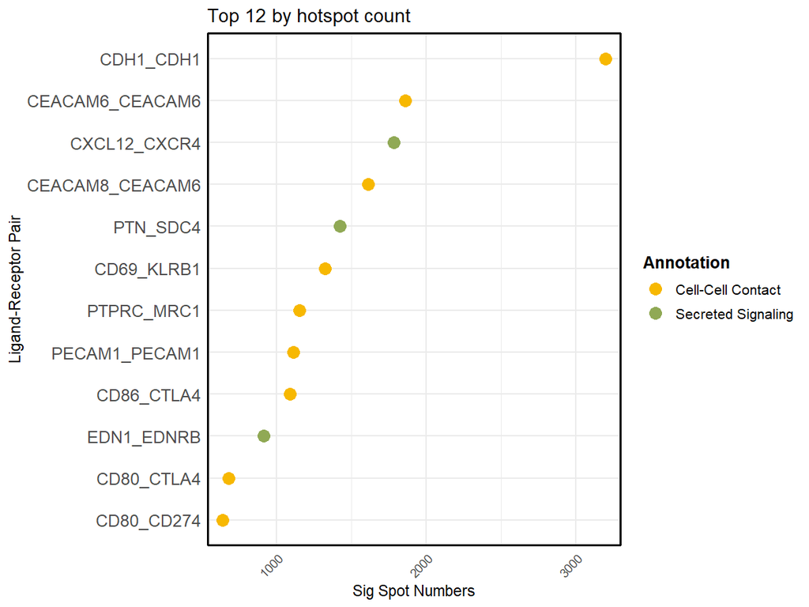

```r
plotLRrank(res, top = 30)
```

## Spatial Map of Hotspot Bins

For a chosen LR pair (here, the top-ranked pair by default), shows which bins are significant hotspots, coloured by p-value or LISA score.

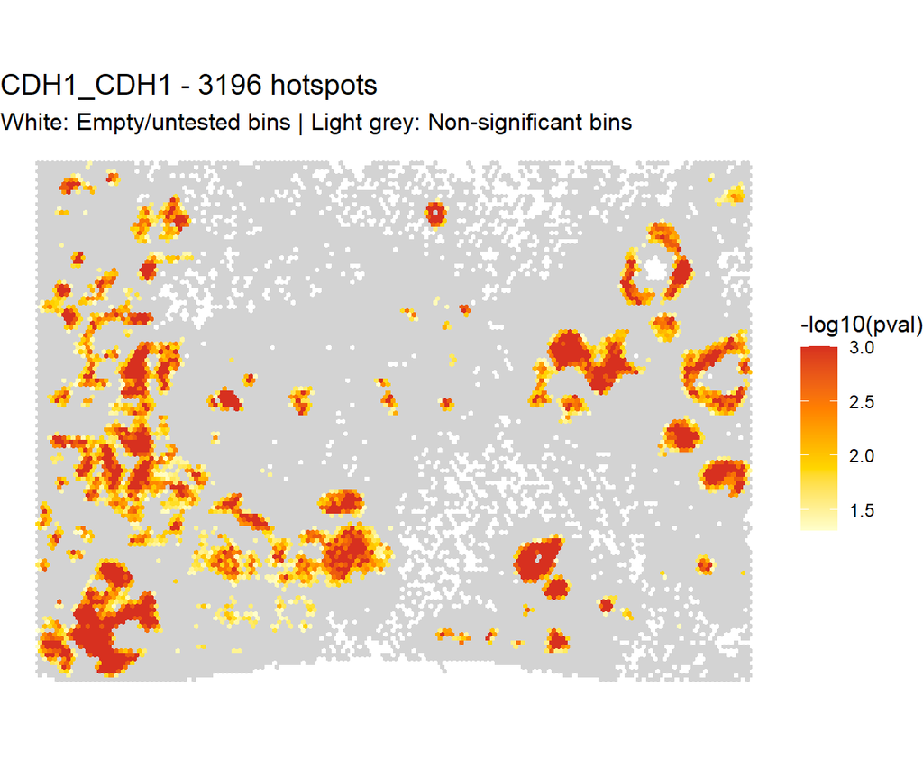

```r
plotHotspots(res, index = 1)
```

```r
# Or by gene names:
# plotHotspots(res, ligand = "CXCL12", receptor = "CXCR4")
```

## Cell-Cell Interaction (CCI) Heatmaps

### Across all LR pairs

Rows are sender→receiver cell-type pairs; columns are LR pairs.

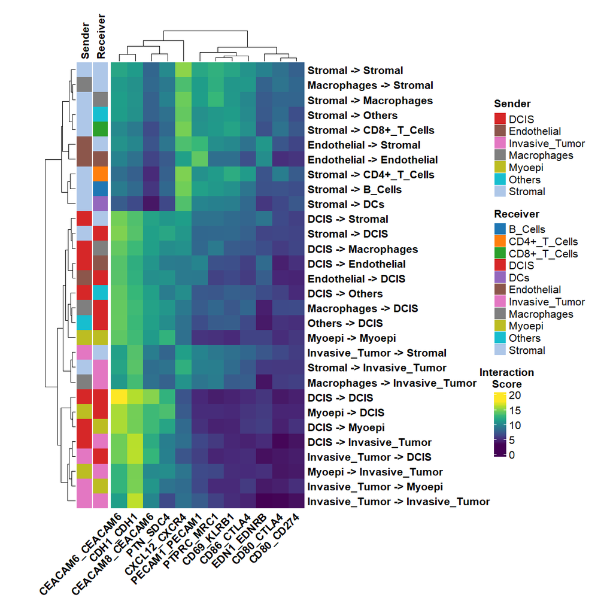

```r
plotCCI(res, top_lr = 20, top_pairs = 30)
```

Filter by specific senders or receivers:

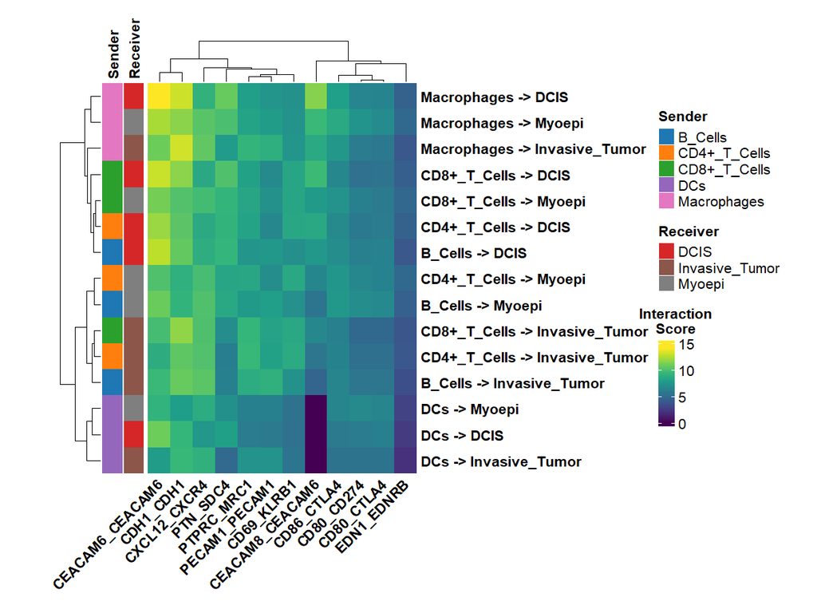

```r
plotCCI(res,
        sender = c("CD4+_T_Cells", "CD8+_T_Cells", "B_Cells",
                   "Macrophages", "DCs"),
        receiver = c("Invasive_Tumor", "DCIS", "Myoepi") )
```

### For a single LR pair

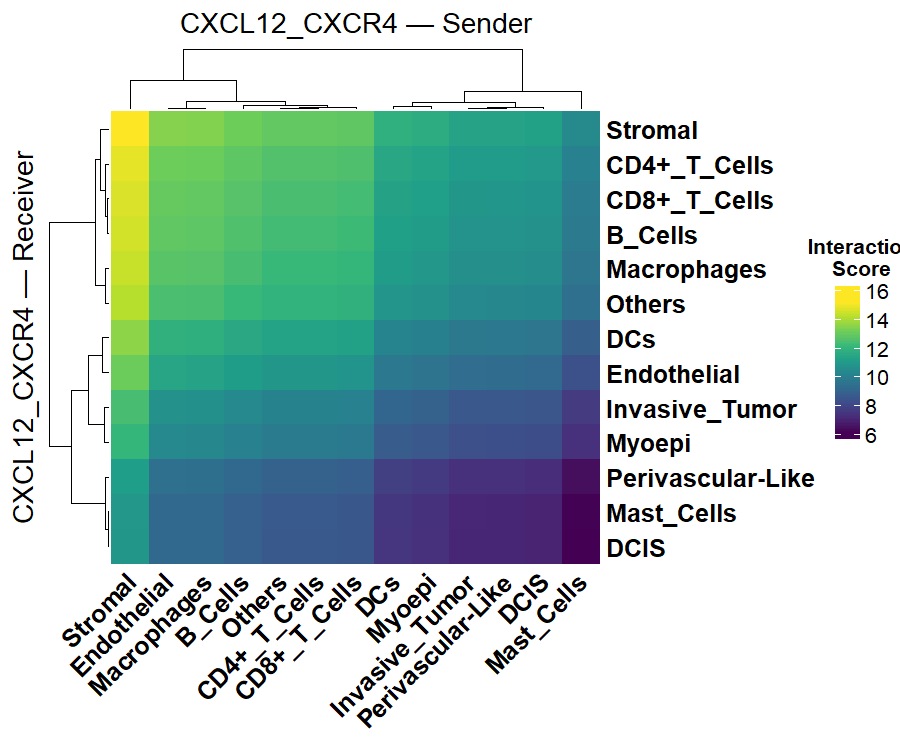

```r
plotCCILR(res, ligand = "CXCL12", receptor = "CXCR4")
```

### Aggregated across LR pairs

Sender × receiver heatmap with scores summed (or any user-supplied function) across all LR pairs:

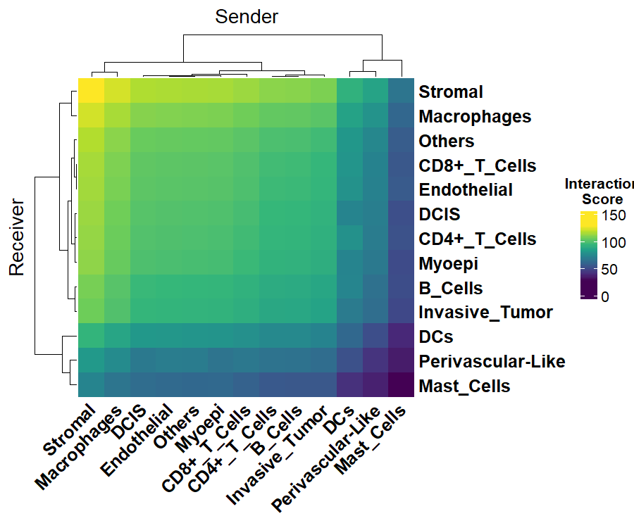

```r
plotCCIsummary(res)
```

```r
# With a different aggregation:
# plotCCIsummary(res, agg_fun = mean)
```

## Spatial Map of Dominant Cell-Type Pairs

For each hotspot bin of a chosen LR pair, identifies the dominant sender→receiver cell-type combination based on ligand expression in the neighbourhood and receptor expression inside the bin.

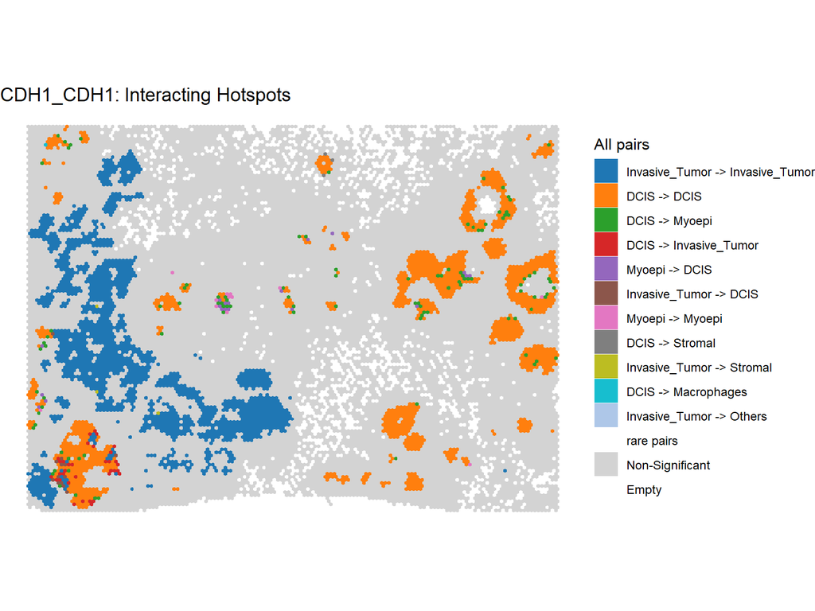

```r
plotCCIspatial(
  res,
  counts_by_group = binned$counts_by_group,
  index = 1
)
```